# Figure 1: Calculating Sensitivity and Confidence Intervals

Diana Proctor

9/8/2020

last updated: April 22 2021

**draft: submission to Nature Medicine October 2020, Revised submission Feb 2021**

*Manuscript Title*: Integrated genomic, epidemiologic investigation of Candida auris skin colonization in a skilled nursing facility

*Authors*: Diana M Proctor1, Thelma Dangana2, D. Joseph Sexton3, Christine Fukuda2, Rachel D Yelin2, Mary Stanley2, Pamela B Bell2, Sangeetha Baskaran2, Clay Deming1, Qiong Chen1, Sean Conlan1, Morgan Park4, NISC Comparative Sequencing Program4, Rory M Welsh3, Snigdha Vallabhaneni3,5, Tom Chiller3, Kaitlin Forsberg3, Stephanie R. Black6, Massimo Pacilli6, Heidi H Kong7, Michael Y Lin2, Michael E Schoeny8, Anastasia P Litvintseva3, Julia A Segre1+, Mary K Hayden2+

*Affiliations*:

- 1Microbial Genomics Section, Translational and Functional Genomics Branch, National Human Genome Research Institute, National Institutes of Health, Bethesda, MD 20892, USA
- 2 Department of Internal Medicine, Division of Infectious Diseases, Rush University Medical Center, Chicago, IL 60612, USA.
- 3Mycotic Diseases Branch, Centers for Disease Control and Prevention, Atlanta, GA 30333, USA.
- 4NIH Intramural Sequencing Center, National Human Genome Research Institute, National Institutes of Health, Bethesda, MD 20892, USA.
- 5Division of Healthcare Quality Promotion, NCEZID, CDC, USA
- 6Communicable Disease Program, Chicago Department of Public Health, Chicago, IL, 60612, USA.
- 7Dermatology Branch, National Institute of Arthritis and Musculoskeletal and Skin Diseases, National Institutes of Health, Bethesda, MD 20892, USA
- 8College of Nursing, Rush University, Chicago, IL 60612, USA.
- +Contributed equally

#### Description of the dataset

Here, we seek to evaluate the total body site occupancy of Candida auris on the body, as well as estimate prevalence (defined in this script as the proportion of all patients colonized using different combinations of body sites), as well as compute the sensitivity of each body site in capturing the percentage of patients who are colonized by Candida auris, at any body site. Sensitivity is defined as the estimated prevalence / number of colonized patients, according to any body site. We compute these estimates based on culture results for each of 57 patients.

To accomplish this, we read in the following data:

1. sitecode_to_factored_sites.csv
2. Cauris_Analytic_2020-5-20.csv

#### Here, we render the following figures:

- Figure 1
- Supplementary Figure 2: Ridgeline Plot of CFUs
- Supplementary Figure 1: UpsetR plot of body site colonization patterns
- Supplementary Figure 3: Paired MPN Analysis

Install and Load R packages

```r
 #load package method from from Dan Sprokett

# set seed
set.seed(78979)

#define packages
packages <- c("knitr",
              "tidyverse",
              "epiR",
              "viridis",
              "scales",
              "kableExtra",
              "UpSetR",
              "reshape2",
              "gridExtra",
              "phyloseq",
              "wesanderson",
              "harrypotter",
              "ggridges",
              "ggpubr",
              "dabestr",
              "ComplexHeatmap",
              "scales",
              "cowplot",
              "Hmisc")

# install packages from bioconductor
BiocManager::install(setdiff(packages,installed.packages()), update=FALSE)
n <- length(packages) - sum(sapply(packages,require,character.only=TRUE))

# print if packages loaded properly
if(n == 0){
  print("All necessary R packages loaded properly")
} else {
  print(paste0(n, " R packages did not load properly"))
}
```

```
## [1] "All necessary R packages loaded properly"
```

define knitr options

```r
knitr::opts_chunk$set(echo=TRUE, warning=FALSE, message=FALSE, error = FALSE)
```

#### 1. Let's see how to compute prevalence estimates and confidence intervals using the epi.test pacckage

We will use the epiR package to get the body site sensitivities for Candida auris colonization.

Compute the sensitivity of each body site for classification of colonization positive patients. Note that we do not have information for false negatives or false positives. We will use only information regarding true positives and true negatives in these calculations.

We define a function that takes as input 3 arguments:

- df is dataframe, having the columns (SiteID, Survey_Period);
- ref_sites is a vector of sites for which the sensitivity is being defined;
- time is the numeric survey period to analyze.

The output is a data frame with:

- the fraction of sites that were positive (TP/TP+TN)
- the lower 95% CI
- the upper 95% CI
- the ref_sites
- ncompare, which is the length of ref_sites, which is = number of sites being compared.

We use the epi.test package as before.

```r
get_sensitivity_interval_notime <- function(df,  ref_sites){
  df=  df[df[["SiteID"]] %in% ref_sites,]

    #get the numbers of positives and negatives
    df = doBy::summaryBy(Cauris_Result~Unique_ptid, data=df, FUN=sum, na.rm=TRUE)
    df$Count = ifelse(df$Cauris_Result.sum > 0, 1, 0)
    TP = sum(df$Count == 1)
    TN = sum(df$Count == 0)

    dat <- as.table(matrix(c(TP, 0, TN, 0), nrow=2, byrow=TRUE))
    out = epi.tests(dat, conf.level = 0.95)
    out1 = out$rval$se
    out1$ncompare = length(ref_sites)
    rownames(out1) = toString(ref_sites)

    return(out1)

}
```

#### Let's look at a table provided by collaborators as a test case

First we test this package out on the data set in the paper Thurlow et al, 2013. Anatomic sites of patient colonization and environmental contamination with Klebsiella pneumoniae Carbapenemase-producing Enterobacteriaceae at Long Term Acute Care Hospitals. Infection Control & Hospital Epidemiology. 34(1). We use the data from table 2 as an example. This is the table from which data are drawn.

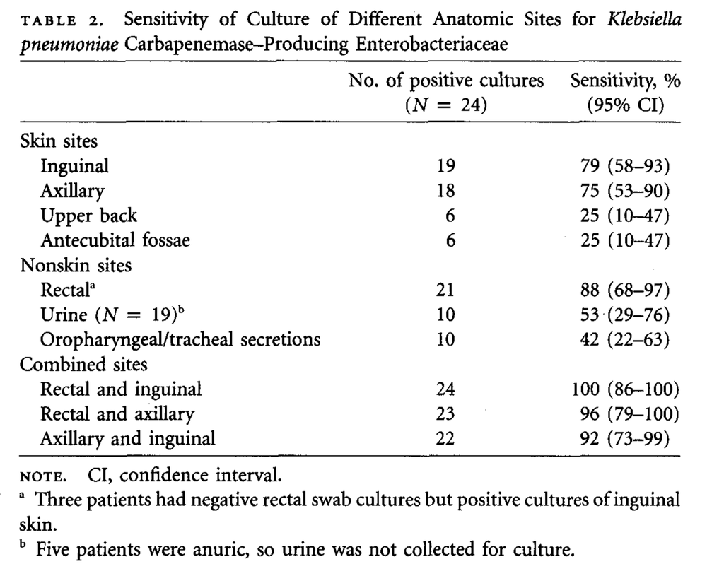

Table 2

**What does our table look like?** Okay, this looks good. Our estimates and confidence intervals are the same as in the published paper. Let's move on to our data.

Replicate Table 2

|  | est | lower | upper |
| --- | --- | --- | --- |
| **Skin sites** |  |  |  |
| Inguinal | 0.79 | 0.58 | 0.93 |
| Axillary | 0.75 | 0.53 | 0.90 |
| Upper Back | 0.25 | 0.10 | 0.47 |
| Antecubital fossa | 0.25 | 0.10 | 0.47 |
| **Nonskin Sites** |  |  |  |
| Rectal | 0.88 | 0.68 | 0.97 |
| Urine | 0.53 | 0.29 | 0.76 |
| **Combined sites** |  |  |  |
| Oropharyngeal | 0.42 | 0.22 | 0.63 |
| Rectal and Inguinal | 1.00 | 0.86 | 1.00 |
| Retal and Axillary | 0.96 | 0.79 | 1.00 |
| Axillary and Inguinal | 0.92 | 0.73 | 0.99 |

Note:  
CI = Confidence Interval

#### 2.Now let's make the equivalent table for the Candida auris paper.

First read in the data

```r
site_codes = read.csv("~/Desktop/candida_auris_rush/sitecode_to_factored_sites.csv")
data = read.csv("~/Desktop/candida_auris_rush/manuscript/data/Cauris_Analytic_2020-5-20.csv") %>%
  dplyr::select(., c("Unique_ptid", "Survey_Period", "Cauris_Result", "site")) %>%
  plyr::join(., site_codes)
mpn = read.csv("~/Desktop/candida_auris_rush/manuscript/data/Cauris_Analytic_2020-5-20.csv") %>%
  dplyr::select(., c("Unique_ptid", "Survey_Period", "Cauris_Result", "site", "CDC_MPN", "CFUTransform_Cauris")) %>%
  plyr::join(., site_codes)
```

how many subjects were included in each survey?

- survey 1: 56
- survey 2: 45
- survey 3: 43

```r
#how many subjects are in the first survey
total=subset(data, Survey_Period==1)
totalN = length(unique(total$Unique_ptid))
totalN
```

```
## [1] 56
```

```r
#how many subjects are in the seccond survey
total=subset(data, Survey_Period==2)
totalN = length(unique(total$Unique_ptid))
totalN
```

```
## [1] 45
```

```r
#how many subjects are in the third survey
total=subset(data, Survey_Period==3)
totalN = length(unique(total$Unique_ptid))
totalN
```

```
## [1] 43
```

#### Define the working datset - newdata1

- this includes 57 subjects
- 56 were surveyed on survey 1
- 1 (subject 29) was surveyed on survey 2

```r
#############define the dataset
# for the dataset we have 57 subjects
#56 were sampled on survey 1
#1 was sampled on survey 2 (subject 29)
########################
############# Let's subset on the first time point so that we don't have 2-3 entries per patient
newdata1 = subset(data, Survey_Period==1)

#note that subject 29 was not sampled on day 1, just on day 2, so let's grab that individual, subsetting on time point 2 only
subject29 = subset(data, Unique_ptid=="29" & Survey_Period=="2")
newdata1 = data.frame(rbind(newdata1, subject29))

#verify we have 57 subjects
length(unique(newdata1$Unique_ptid))
```

```
## [1] 57
```

#### One-way: Site-wise computation of proportion of colonized patients based on each site

Let's run the function for the various comparisons of interest

[output not shown]

Sensitivity Analysis

|  | Prevalence | 95% CI, Lower | 95% CI, Upper | N.Sites |
| --- | --- | --- | --- | --- |
| N | 0.4285714 | 0.2971209 | 0.5678410 | 1 |
| Fg | 0.4035088 | 0.2756127 | 0.5417866 | 1 |
| Tw | 0.3571429 | 0.2335548 | 0.4964069 | 1 |
| An | 0.3529412 | 0.2243062 | 0.4993180 | 1 |
| Ic | 0.3392857 | 0.2181093 | 0.4781137 | 1 |
| Ax | 0.3035714 | 0.1877987 | 0.4409674 | 1 |
| Bu/To | 0.2142857 | 0.1159222 | 0.3443954 | 1 |
| Tc | 0.1219512 | 0.0408067 | 0.2620447 | 1 |
| Ne | 0.0877193 | 0.0290986 | 0.1929573 | 1 |
| Ea | 0.0714286 | 0.0198039 | 0.1729047 | 1 |

#### all two way

- we want to pick the combination of sites (1-way, 2-way, 3-way, etc.) that adds a marginal benefit to the prior set of samples to a master table
- we sort the 2-way comparisons to identify the 2-way site comparisons that maximize our estimate of the proportion of positive patients

```r
set.seed(91)
alltwosites = combn(unique(newdata1$SiteID)[1:10], 2, simplify = TRUE)


 holder <- vector("list", ncol(alltwosites))
  for(i in 1:ncol(alltwosites)) {
        twoway1  = get_sensitivity_interval_notime(df=newdata1,
                                                   ref_sites = alltwosites[,i])
      holder[[i]] =  twoway1
}

CI.twoway = do.call("rbind", holder)
colnames(CI.twoway) = c("Prevalence", "95% CI, Lower", "95% CI, Upper", "N.Sites")
CI.twoway = CI.twoway %>%
  arrange(., desc(`Prevalence`))

kable(CI.twoway, caption = "Sensitivity Analysis") %>%
  kable_styling("basic", full_width = F, bootstrap_options ="condensed")
```

Sensitivity Analysis

|  | Prevalence | 95% CI, Lower | 95% CI, Upper | N.Sites |
| --- | --- | --- | --- | --- |
| N, Fg | 0.6140351 | 0.4757484 | 0.7400453 | 2 |
| Tw, N | 0.5714286 | 0.4321590 | 0.7028791 | 2 |
| Tw, Fg | 0.5614035 | 0.4236214 | 0.6925846 | 2 |
| Ic, N | 0.5535714 | 0.4147167 | 0.6865639 | 2 |
| An, Fg | 0.5438596 | 0.4065597 | 0.6764458 | 2 |
| Ic, Fg | 0.5438596 | 0.4065597 | 0.6764458 | 2 |
| N, Ax | 0.5357143 | 0.3974360 | 0.6700853 | 2 |
| An, N | 0.5178571 | 0.3803158 | 0.6534451 | 2 |
| Tw, An | 0.5000000 | 0.3633554 | 0.6366446 | 2 |
| Tw, Ic | 0.5000000 | 0.3633554 | 0.6366446 | 2 |
| Ic, Ax | 0.5000000 | 0.3633554 | 0.6366446 | 2 |
| Bu/To, Fg | 0.4912281 | 0.3562965 | 0.6271021 | 2 |
| Tw, Ax | 0.4821429 | 0.3465549 | 0.6196842 | 2 |
| An, Ic | 0.4821429 | 0.3465549 | 0.6196842 | 2 |
| Ax, Fg | 0.4736842 | 0.3398483 | 0.6103478 | 2 |
| An, Ax | 0.4642857 | 0.3299147 | 0.6025640 | 2 |
| Ne, N | 0.4561404 | 0.3235542 | 0.5934403 | 2 |
| An, Bu/To | 0.4464286 | 0.3134361 | 0.5852833 | 2 |
| Ic, Bu/To | 0.4464286 | 0.3134361 | 0.5852833 | 2 |
| Bu/To, N | 0.4464286 | 0.3134361 | 0.5852833 | 2 |
| N, Ea | 0.4464286 | 0.3134361 | 0.5852833 | 2 |
| Ea, Fg | 0.4385965 | 0.3074154 | 0.5763786 | 2 |
| Tw, Bu/To | 0.4285714 | 0.2971209 | 0.5678410 | 2 |
| Tc, N | 0.4285714 | 0.2971209 | 0.5678410 | 2 |
| Bu/To, Ax | 0.4285714 | 0.2971209 | 0.5678410 | 2 |
| Ne, Fg | 0.4210526 | 0.2914341 | 0.5591614 | 2 |
| Tc, Fg | 0.4210526 | 0.2914341 | 0.5591614 | 2 |
| Tw, Ea | 0.3928571 | 0.2649913 | 0.5324631 | 2 |
| Ne, Tw | 0.3859649 | 0.2599547 | 0.5242516 | 2 |
| Ne, Ic | 0.3859649 | 0.2599547 | 0.5242516 | 2 |
| Tw, Tc | 0.3750000 | 0.2491841 | 0.5145217 | 2 |
| Ic, Tc | 0.3750000 | 0.2491841 | 0.5145217 | 2 |
| Ic, Ea | 0.3750000 | 0.2491841 | 0.5145217 | 2 |
| An, Tc | 0.3703704 | 0.2429070 | 0.5125826 | 2 |
| Ne, An | 0.3684211 | 0.2444640 | 0.5065530 | 2 |
| Ea, Ax | 0.3571429 | 0.2335548 | 0.4964069 | 2 |
| An, Ea | 0.3392857 | 0.2181093 | 0.4781137 | 2 |
| Tc, Ax | 0.3392857 | 0.2181093 | 0.4781137 | 2 |
| Ne, Ax | 0.3333333 | 0.2140053 | 0.4706476 | 2 |
| Bu/To, Ea | 0.2857143 | 0.1729518 | 0.4220987 | 2 |
| Ne, Bu/To | 0.2807018 | 0.1697292 | 0.4154289 | 2 |
| Tc, Bu/To | 0.2321429 | 0.1297920 | 0.3641843 | 2 |
| Tc, Ea | 0.1607143 | 0.0762187 | 0.2832797 | 2 |
| Ne, Tc | 0.1578947 | 0.0748312 | 0.2786826 | 2 |
| Ne, Ea | 0.1228070 | 0.0508289 | 0.2367950 | 2 |

#### Three way

- we want to pick the combination of sites (1-way, 2-way, 3-way, etc.) that adds a marginal benefit to the prior set of samples to a master table
- we sort the 3-way comparisons to identify the 3-way site comparisons that maximize our estimate of the proportion of positive patients

```r
all3 = combn(unique(newdata1$SiteID)[1:10], 3, simplify = TRUE)

 holder <- vector("list", ncol(all3))
  for(i in 1:ncol(all3)) {
        df  = get_sensitivity_interval_notime(df=newdata1, ref_sites = all3[,i])
      holder[[i]] =  df
}

CI.threeway = do.call("rbind", holder)
colnames(CI.threeway) = c("Prevalence", "95% CI, Lower", "95% CI, Upper", "N.Sites")
CI.threeway = CI.threeway %>%
  arrange(., desc(`Prevalence`))

kable(CI.threeway, caption = "Sensitivity Analysis") %>%
  kable_styling("basic", full_width = F, bootstrap_options ="condensed")
```

Sensitivity Analysis

|  | Prevalence | 95% CI, Lower | 95% CI, Upper | N.Sites |
| --- | --- | --- | --- | --- |
| Tw, N, Fg | 0.7192982 | 0.5845711 | 0.8302708 | 3 |
| Ic, N, Fg | 0.7017544 | 0.5659736 | 0.8157119 | 3 |
| An, N, Fg | 0.6842105 | 0.5475702 | 0.8009499 | 3 |
| Tw, An, Fg | 0.6666667 | 0.5293524 | 0.7859947 | 3 |
| Tw, N, Ax | 0.6607143 | 0.5218863 | 0.7818907 | 3 |
| N, Ax, Fg | 0.6491228 | 0.5113134 | 0.7708544 | 3 |
| Ic, N, Ax | 0.6428571 | 0.5035931 | 0.7664452 | 3 |
| Tw, Ic, Fg | 0.6315789 | 0.4934470 | 0.7555360 | 3 |
| An, Ic, Fg | 0.6315789 | 0.4934470 | 0.7555360 | 3 |
| Bu/To, N, Fg | 0.6315789 | 0.4934470 | 0.7555360 | 3 |
| Tw, An, N | 0.6250000 | 0.4854783 | 0.7508159 | 3 |
| Tw, Ic, N | 0.6250000 | 0.4854783 | 0.7508159 | 3 |
| An, Ic, N | 0.6250000 | 0.4854783 | 0.7508159 | 3 |
| Ne, N, Fg | 0.6140351 | 0.4757484 | 0.7400453 | 3 |
| An, Bu/To, Fg | 0.6140351 | 0.4757484 | 0.7400453 | 3 |
| Ic, Bu/To, Fg | 0.6140351 | 0.4757484 | 0.7400453 | 3 |
| Tc, N, Fg | 0.6140351 | 0.4757484 | 0.7400453 | 3 |
| N, Ea, Fg | 0.6140351 | 0.4757484 | 0.7400453 | 3 |
| An, N, Ax | 0.6071429 | 0.4675369 | 0.7350087 | 3 |
| Tw, Bu/To, Fg | 0.5964912 | 0.4582134 | 0.7243873 | 3 |
| Tw, Ea, Fg | 0.5964912 | 0.4582134 | 0.7243873 | 3 |
| Tw, Ax, Fg | 0.5964912 | 0.4582134 | 0.7243873 | 3 |
| An, Ax, Fg | 0.5964912 | 0.4582134 | 0.7243873 | 3 |
| Tw, An, Ic | 0.5892857 | 0.4497649 | 0.7190285 | 3 |
| Tw, An, Ax | 0.5892857 | 0.4497649 | 0.7190285 | 3 |
| Tw, Ic, Ax | 0.5892857 | 0.4497649 | 0.7190285 | 3 |
| An, Ic, Ax | 0.5892857 | 0.4497649 | 0.7190285 | 3 |
| Ne, Tw, N | 0.5789474 | 0.4408386 | 0.7085659 | 3 |
| Ne, Tw, Fg | 0.5789474 | 0.4408386 | 0.7085659 | 3 |
| Tw, Tc, Fg | 0.5789474 | 0.4408386 | 0.7085659 | 3 |

[output cut: 90 more lines]

#### Four way

- we want to pick the combination of sites (1-way, 2-way, 3-way, etc.) that adds a marginal benefit to the prior set of samples to a master table
- we sort the 4-way comparisons to identify the 4-way site comparisons that maximize our estimate of the proportion of positive patients

```r
all4 = combn(unique(newdata1$SiteID)[1:10], 4, simplify = TRUE)

 holder <- vector("list", ncol(all4))
  for(i in 1:ncol(all4)) {
        df  = get_sensitivity_interval_notime(df=newdata1, ref_sites = all4[,i])
      holder[[i]] =  df
}

CI.fourway = do.call("rbind", holder)
colnames(CI.fourway) = c("Prevalence", "95% CI, Lower", "95% CI, Upper", "N.Sites")
CI.fourway = CI.fourway %>%
  arrange(., desc(`Prevalence`))

kable(CI.fourway, caption = "Sensitivity Analysis") %>%
  kable_styling("basic", full_width = F, bootstrap_options ="condensed")
```

Sensitivity Analysis

|  | Prevalence | 95% CI, Lower | 95% CI, Upper | N.Sites |
| --- | --- | --- | --- | --- |
| Tw, An, N, Fg | 0.7543860 | 0.6223897 | 0.8587314 | 4 |
| Tw, Ic, N, Fg | 0.7543860 | 0.6223897 | 0.8587314 | 4 |
| An, Ic, N, Fg | 0.7543860 | 0.6223897 | 0.8587314 | 4 |
| Tw, N, Ax, Fg | 0.7368421 | 0.6033725 | 0.8446152 | 4 |
| Ne, Tw, N, Fg | 0.7192982 | 0.5845711 | 0.8302708 | 4 |
| Tw, Tc, N, Fg | 0.7192982 | 0.5845711 | 0.8302708 | 4 |
| Tw, Bu/To, N, Fg | 0.7192982 | 0.5845711 | 0.8302708 | 4 |
| Tw, N, Ea, Fg | 0.7192982 | 0.5845711 | 0.8302708 | 4 |
| An, N, Ax, Fg | 0.7192982 | 0.5845711 | 0.8302708 | 4 |
| Ic, Bu/To, N, Fg | 0.7192982 | 0.5845711 | 0.8302708 | 4 |
| Ic, N, Ax, Fg | 0.7192982 | 0.5845711 | 0.8302708 | 4 |
| Tw, Ic, N, Ax | 0.7142857 | 0.5779013 | 0.8270482 | 4 |
| Ne, Ic, N, Fg | 0.7017544 | 0.5659736 | 0.8157119 | 4 |
| Tw, An, Ic, Fg | 0.7017544 | 0.5659736 | 0.8157119 | 4 |
| Tw, An, Bu/To, Fg | 0.7017544 | 0.5659736 | 0.8157119 | 4 |
| Ic, Tc, N, Fg | 0.7017544 | 0.5659736 | 0.8157119 | 4 |
| Ic, N, Ea, Fg | 0.7017544 | 0.5659736 | 0.8157119 | 4 |
| Tw, An, N, Ax | 0.6964286 | 0.5590326 | 0.8122013 | 4 |
| An, Ic, N, Ax | 0.6964286 | 0.5590326 | 0.8122013 | 4 |
| Ne, Tw, An, Fg | 0.6842105 | 0.5475702 | 0.8009499 | 4 |
| Ne, An, N, Fg | 0.6842105 | 0.5475702 | 0.8009499 | 4 |
| Tw, An, Tc, Fg | 0.6842105 | 0.5475702 | 0.8009499 | 4 |
| Tw, An, Ax, Fg | 0.6842105 | 0.5475702 | 0.8009499 | 4 |
| An, Ic, Bu/To, Fg | 0.6842105 | 0.5475702 | 0.8009499 | 4 |
| An, Tc, N, Fg | 0.6842105 | 0.5475702 | 0.8009499 | 4 |
| An, Bu/To, N, Fg | 0.6842105 | 0.5475702 | 0.8009499 | 4 |
| An, N, Ea, Fg | 0.6842105 | 0.5475702 | 0.8009499 | 4 |
| Tw, An, Ic, N | 0.6785714 | 0.5403638 | 0.7971455 | 4 |
| Tw, An, Ea, Fg | 0.6666667 | 0.5293524 | 0.7859947 | 4 |
| Tw, Ic, Bu/To, Fg | 0.6666667 | 0.5293524 | 0.7859947 | 4 |

[output cut: 180 more lines]

#### Five way

- we want to pick the combination of sites (1-way, 2-way, 3-way, etc.) that adds a marginal benefit to the prior set of samples to a master table
- we sort the 5-way comparisons to identify the 5-way site comparisons that maximize our estimate of the proportion of positive patients

```r
all5 = combn(unique(newdata1$SiteID)[1:10], 5, simplify = TRUE)

 holder <- vector("list", ncol(all5))
  for(i in 1:ncol(all5)) {
        df  = get_sensitivity_interval_notime(df=newdata1, ref_sites = all5[,i])
      holder[[i]] =  df
}

CI.fiveway = do.call("rbind", holder)
colnames(CI.fiveway) = c("Prevalence", "95% CI, Lower", "95% CI, Upper", "N.Sites")
CI.fiveway = CI.fiveway %>%
  arrange(., desc(`Prevalence`))

kable(CI.fiveway, caption = "Sensitivity Analysis") %>%
  kable_styling("basic", full_width = F, bootstrap_options ="condensed")
```

Sensitivity Analysis

|  | Prevalence | 95% CI, Lower | 95% CI, Upper | N.Sites |
| --- | --- | --- | --- | --- |
| Tw, An, Ic, N, Fg | 0.7894737 | 0.6611299 | 0.8862098 | 5 |
| Tw, An, N, Ax, Fg | 0.7719298 | 0.6416366 | 0.8726029 | 5 |
| Tw, Ic, N, Ax, Fg | 0.7719298 | 0.6416366 | 0.8726029 | 5 |
| An, Ic, N, Ax, Fg | 0.7719298 | 0.6416366 | 0.8726029 | 5 |
| Ne, Tw, An, N, Fg | 0.7543860 | 0.6223897 | 0.8587314 | 5 |
| Ne, Tw, Ic, N, Fg | 0.7543860 | 0.6223897 | 0.8587314 | 5 |
| Ne, An, Ic, N, Fg | 0.7543860 | 0.6223897 | 0.8587314 | 5 |
| Tw, An, Tc, N, Fg | 0.7543860 | 0.6223897 | 0.8587314 | 5 |
| Tw, An, Bu/To, N, Fg | 0.7543860 | 0.6223897 | 0.8587314 | 5 |
| Tw, An, N, Ea, Fg | 0.7543860 | 0.6223897 | 0.8587314 | 5 |
| Tw, Ic, Tc, N, Fg | 0.7543860 | 0.6223897 | 0.8587314 | 5 |
| Tw, Ic, Bu/To, N, Fg | 0.7543860 | 0.6223897 | 0.8587314 | 5 |
| Tw, Ic, N, Ea, Fg | 0.7543860 | 0.6223897 | 0.8587314 | 5 |
| An, Ic, Tc, N, Fg | 0.7543860 | 0.6223897 | 0.8587314 | 5 |
| An, Ic, Bu/To, N, Fg | 0.7543860 | 0.6223897 | 0.8587314 | 5 |
| An, Ic, N, Ea, Fg | 0.7543860 | 0.6223897 | 0.8587314 | 5 |
| Tw, An, Ic, N, Ax | 0.7500000 | 0.6162798 | 0.8560669 | 5 |
| Ne, Tw, N, Ax, Fg | 0.7368421 | 0.6033725 | 0.8446152 | 5 |
| Tw, An, Ic, Bu/To, Fg | 0.7368421 | 0.6033725 | 0.8446152 | 5 |
| Tw, Tc, N, Ax, Fg | 0.7368421 | 0.6033725 | 0.8446152 | 5 |
| Tw, Bu/To, N, Ax, Fg | 0.7368421 | 0.6033725 | 0.8446152 | 5 |
| Tw, N, Ea, Ax, Fg | 0.7368421 | 0.6033725 | 0.8446152 | 5 |
| Ic, Bu/To, N, Ax, Fg | 0.7368421 | 0.6033725 | 0.8446152 | 5 |
| Ne, Tw, An, Ic, Fg | 0.7192982 | 0.5845711 | 0.8302708 | 5 |
| Ne, Tw, Tc, N, Fg | 0.7192982 | 0.5845711 | 0.8302708 | 5 |
| Ne, Tw, Bu/To, N, Fg | 0.7192982 | 0.5845711 | 0.8302708 | 5 |
| Ne, Tw, N, Ea, Fg | 0.7192982 | 0.5845711 | 0.8302708 | 5 |
| Ne, An, N, Ax, Fg | 0.7192982 | 0.5845711 | 0.8302708 | 5 |
| Ne, Ic, Bu/To, N, Fg | 0.7192982 | 0.5845711 | 0.8302708 | 5 |
| Ne, Ic, N, Ax, Fg | 0.7192982 | 0.5845711 | 0.8302708 | 5 |

[output cut: 222 more lines]

#### Six way

- we want to pick the combination of sites (1-way, 2-way, 3-way, etc.) that adds a marginal benefit to the prior set of samples to a master table
- we sort the 6-way comparisons to identify the 6-way site comparisons that maximize our estimate of the proportion of positive patients
- 6 sites were required to achieve 100% sensitivity, identifying all patients colonized at any body site

```r
all6 = combn(unique(newdata1$SiteID)[1:10], 6, simplify = TRUE)

 holder <- vector("list", ncol(all6))
  for(i in 1:ncol(all6)) {
        df  = get_sensitivity_interval_notime(df=newdata1, ref_sites = all6[,i])
      holder[[i]] =  df
}

CI.sixway = do.call("rbind", holder)
colnames(CI.sixway) = c("Prevalence", "95% CI, Lower", "95% CI, Upper", "N.Sites")
CI.sixway = CI.sixway %>%
  arrange(., desc(`Prevalence`))

kable(CI.sixway, caption = "Sensitivity Analysis") %>%
  kable_styling("basic", full_width = F, bootstrap_options ="condensed")
```

Sensitivity Analysis

|  | Prevalence | 95% CI, Lower | 95% CI, Upper | N.Sites |
| --- | --- | --- | --- | --- |
| Tw, An, Ic, N, Ax, Fg | 0.8070175 | 0.6808902 | 0.8995278 | 6 |
| Ne, Tw, An, Ic, N, Fg | 0.7894737 | 0.6611299 | 0.8862098 | 6 |
| Tw, An, Ic, Tc, N, Fg | 0.7894737 | 0.6611299 | 0.8862098 | 6 |
| Tw, An, Ic, Bu/To, N, Fg | 0.7894737 | 0.6611299 | 0.8862098 | 6 |
| Tw, An, Ic, N, Ea, Fg | 0.7894737 | 0.6611299 | 0.8862098 | 6 |
| Ne, Tw, An, N, Ax, Fg | 0.7719298 | 0.6416366 | 0.8726029 | 6 |
| Ne, Tw, Ic, N, Ax, Fg | 0.7719298 | 0.6416366 | 0.8726029 | 6 |
| Ne, An, Ic, N, Ax, Fg | 0.7719298 | 0.6416366 | 0.8726029 | 6 |
| Tw, An, Tc, N, Ax, Fg | 0.7719298 | 0.6416366 | 0.8726029 | 6 |
| Tw, An, Bu/To, N, Ax, Fg | 0.7719298 | 0.6416366 | 0.8726029 | 6 |
| Tw, An, N, Ea, Ax, Fg | 0.7719298 | 0.6416366 | 0.8726029 | 6 |
| Tw, Ic, Tc, N, Ax, Fg | 0.7719298 | 0.6416366 | 0.8726029 | 6 |
| Tw, Ic, Bu/To, N, Ax, Fg | 0.7719298 | 0.6416366 | 0.8726029 | 6 |
| Tw, Ic, N, Ea, Ax, Fg | 0.7719298 | 0.6416366 | 0.8726029 | 6 |
| An, Ic, Tc, N, Ax, Fg | 0.7719298 | 0.6416366 | 0.8726029 | 6 |
| An, Ic, Bu/To, N, Ax, Fg | 0.7719298 | 0.6416366 | 0.8726029 | 6 |
| An, Ic, N, Ea, Ax, Fg | 0.7719298 | 0.6416366 | 0.8726029 | 6 |
| Ne, Tw, An, Tc, N, Fg | 0.7543860 | 0.6223897 | 0.8587314 | 6 |
| Ne, Tw, An, Bu/To, N, Fg | 0.7543860 | 0.6223897 | 0.8587314 | 6 |
| Ne, Tw, An, N, Ea, Fg | 0.7543860 | 0.6223897 | 0.8587314 | 6 |
| Ne, Tw, Ic, Tc, N, Fg | 0.7543860 | 0.6223897 | 0.8587314 | 6 |
| Ne, Tw, Ic, Bu/To, N, Fg | 0.7543860 | 0.6223897 | 0.8587314 | 6 |
| Ne, Tw, Ic, N, Ea, Fg | 0.7543860 | 0.6223897 | 0.8587314 | 6 |
| Ne, An, Ic, Tc, N, Fg | 0.7543860 | 0.6223897 | 0.8587314 | 6 |
| Ne, An, Ic, Bu/To, N, Fg | 0.7543860 | 0.6223897 | 0.8587314 | 6 |
| Ne, An, Ic, N, Ea, Fg | 0.7543860 | 0.6223897 | 0.8587314 | 6 |
| Tw, An, Ic, Bu/To, Ax, Fg | 0.7543860 | 0.6223897 | 0.8587314 | 6 |
| Tw, An, Tc, Bu/To, N, Fg | 0.7543860 | 0.6223897 | 0.8587314 | 6 |
| Tw, An, Tc, N, Ea, Fg | 0.7543860 | 0.6223897 | 0.8587314 | 6 |
| Tw, An, Bu/To, N, Ea, Fg | 0.7543860 | 0.6223897 | 0.8587314 | 6 |

[output cut: 180 more lines]

#### Seven way

- we want to pick the combination of sites (1-way, 2-way, 3-way, etc.) that adds a marginal benefit to the prior set of samples to a master table
- we sort the 6-way comparisons to identify the 6-way site comparisons that maximize our estimate of the proportion of positive patients
- 6 sites were required to achieve 100% sensitivity, identifying all patients colonized at any body site
- 7-way is shown for completeness

```r
all7 = combn(unique(newdata1$SiteID)[1:10], 7, simplify = TRUE)

 holder <- vector("list", ncol(all7))
  for(i in 1:ncol(all7)) {
        df  = get_sensitivity_interval_notime(df=newdata1, ref_sites = all7[,i])
      holder[[i]] =  df
}

CI.sevenway = do.call("rbind", holder)
colnames(CI.sevenway) = c("Prevalence", "95% CI, Lower", "95% CI, Upper", "N.Sites")
CI.sevenway = CI.sevenway %>%
  arrange(., desc(`Prevalence`))

kable(CI.sevenway, caption = "Sensitivity Analysis") %>%
  kable_styling("basic", full_width = F, bootstrap_options ="condensed")
```

Sensitivity Analysis

|  | Prevalence | 95% CI, Lower | 95% CI, Upper | N.Sites |
| --- | --- | --- | --- | --- |
| Ne, Tw, An, Ic, N, Ax, Fg | 0.8070175 | 0.6808902 | 0.8995278 | 7 |
| Tw, An, Ic, Tc, N, Ax, Fg | 0.8070175 | 0.6808902 | 0.8995278 | 7 |
| Tw, An, Ic, Bu/To, N, Ax, Fg | 0.8070175 | 0.6808902 | 0.8995278 | 7 |
| Tw, An, Ic, N, Ea, Ax, Fg | 0.8070175 | 0.6808902 | 0.8995278 | 7 |
| Ne, Tw, An, Ic, Tc, N, Fg | 0.7894737 | 0.6611299 | 0.8862098 | 7 |
| Ne, Tw, An, Ic, Bu/To, N, Fg | 0.7894737 | 0.6611299 | 0.8862098 | 7 |
| Ne, Tw, An, Ic, N, Ea, Fg | 0.7894737 | 0.6611299 | 0.8862098 | 7 |
| Tw, An, Ic, Tc, Bu/To, N, Fg | 0.7894737 | 0.6611299 | 0.8862098 | 7 |
| Tw, An, Ic, Tc, N, Ea, Fg | 0.7894737 | 0.6611299 | 0.8862098 | 7 |
| Tw, An, Ic, Bu/To, N, Ea, Fg | 0.7894737 | 0.6611299 | 0.8862098 | 7 |
| Ne, Tw, An, Tc, N, Ax, Fg | 0.7719298 | 0.6416366 | 0.8726029 | 7 |
| Ne, Tw, An, Bu/To, N, Ax, Fg | 0.7719298 | 0.6416366 | 0.8726029 | 7 |
| Ne, Tw, An, N, Ea, Ax, Fg | 0.7719298 | 0.6416366 | 0.8726029 | 7 |
| Ne, Tw, Ic, Tc, N, Ax, Fg | 0.7719298 | 0.6416366 | 0.8726029 | 7 |
| Ne, Tw, Ic, Bu/To, N, Ax, Fg | 0.7719298 | 0.6416366 | 0.8726029 | 7 |
| Ne, Tw, Ic, N, Ea, Ax, Fg | 0.7719298 | 0.6416366 | 0.8726029 | 7 |
| Ne, An, Ic, Tc, N, Ax, Fg | 0.7719298 | 0.6416366 | 0.8726029 | 7 |
| Ne, An, Ic, Bu/To, N, Ax, Fg | 0.7719298 | 0.6416366 | 0.8726029 | 7 |
| Ne, An, Ic, N, Ea, Ax, Fg | 0.7719298 | 0.6416366 | 0.8726029 | 7 |
| Tw, An, Tc, Bu/To, N, Ax, Fg | 0.7719298 | 0.6416366 | 0.8726029 | 7 |
| Tw, An, Tc, N, Ea, Ax, Fg | 0.7719298 | 0.6416366 | 0.8726029 | 7 |
| Tw, An, Bu/To, N, Ea, Ax, Fg | 0.7719298 | 0.6416366 | 0.8726029 | 7 |
| Tw, Ic, Tc, Bu/To, N, Ax, Fg | 0.7719298 | 0.6416366 | 0.8726029 | 7 |
| Tw, Ic, Tc, N, Ea, Ax, Fg | 0.7719298 | 0.6416366 | 0.8726029 | 7 |
| Tw, Ic, Bu/To, N, Ea, Ax, Fg | 0.7719298 | 0.6416366 | 0.8726029 | 7 |
| An, Ic, Tc, Bu/To, N, Ax, Fg | 0.7719298 | 0.6416366 | 0.8726029 | 7 |
| An, Ic, Tc, N, Ea, Ax, Fg | 0.7719298 | 0.6416366 | 0.8726029 | 7 |
| An, Ic, Bu/To, N, Ea, Ax, Fg | 0.7719298 | 0.6416366 | 0.8726029 | 7 |
| Ne, Tw, An, Ic, Bu/To, Ax, Fg | 0.7543860 | 0.6223897 | 0.8587314 | 7 |
| Ne, Tw, An, Tc, Bu/To, N, Fg | 0.7543860 | 0.6223897 | 0.8587314 | 7 |

[output cut: 90 more lines]

#### Eight way

- we want to pick the combination of sites (1-way, 2-way, 3-way, etc.) that adds a marginal benefit to the prior set of samples to a master table
- we sort the 6-way comparisons to identify the 6-way site comparisons that maximize our estimate of the proportion of positive patients
- 6 sites were required to achieve 100% sensitivity, identifying all patients colonized at any body site
- 8-way is shown for completeness

```r
all8 = combn(unique(newdata1$SiteID)[1:10], 8, simplify = TRUE)

 holder <- vector("list", ncol(all8))
  for(i in 1:ncol(all8)) {
        df  = get_sensitivity_interval_notime(df=newdata1, ref_sites = all8[,i])
      holder[[i]] =  df
}

CI.eightway = do.call("rbind", holder)
colnames(CI.eightway) = c("Prevalence", "95% CI, Lower", "95% CI, Upper", "N.Sites")
CI.eightway = CI.eightway %>%
  arrange(., desc(`Prevalence`))

kable(CI.eightway, caption = "Sensitivity Analysis") %>%
  kable_styling("basic", full_width = F, bootstrap_options ="condensed")
```

Sensitivity Analysis

|  | Prevalence | 95% CI, Lower | 95% CI, Upper | N.Sites |
| --- | --- | --- | --- | --- |
| Ne, Tw, An, Ic, Tc, N, Ax, Fg | 0.8070175 | 0.6808902 | 0.8995278 | 8 |
| Ne, Tw, An, Ic, Bu/To, N, Ax, Fg | 0.8070175 | 0.6808902 | 0.8995278 | 8 |
| Ne, Tw, An, Ic, N, Ea, Ax, Fg | 0.8070175 | 0.6808902 | 0.8995278 | 8 |
| Tw, An, Ic, Tc, Bu/To, N, Ax, Fg | 0.8070175 | 0.6808902 | 0.8995278 | 8 |
| Tw, An, Ic, Tc, N, Ea, Ax, Fg | 0.8070175 | 0.6808902 | 0.8995278 | 8 |
| Tw, An, Ic, Bu/To, N, Ea, Ax, Fg | 0.8070175 | 0.6808902 | 0.8995278 | 8 |
| Ne, Tw, An, Ic, Tc, Bu/To, N, Fg | 0.7894737 | 0.6611299 | 0.8862098 | 8 |
| Ne, Tw, An, Ic, Tc, N, Ea, Fg | 0.7894737 | 0.6611299 | 0.8862098 | 8 |
| Ne, Tw, An, Ic, Bu/To, N, Ea, Fg | 0.7894737 | 0.6611299 | 0.8862098 | 8 |
| Tw, An, Ic, Tc, Bu/To, N, Ea, Fg | 0.7894737 | 0.6611299 | 0.8862098 | 8 |
| Ne, Tw, An, Tc, Bu/To, N, Ax, Fg | 0.7719298 | 0.6416366 | 0.8726029 | 8 |
| Ne, Tw, An, Tc, N, Ea, Ax, Fg | 0.7719298 | 0.6416366 | 0.8726029 | 8 |
| Ne, Tw, An, Bu/To, N, Ea, Ax, Fg | 0.7719298 | 0.6416366 | 0.8726029 | 8 |
| Ne, Tw, Ic, Tc, Bu/To, N, Ax, Fg | 0.7719298 | 0.6416366 | 0.8726029 | 8 |
| Ne, Tw, Ic, Tc, N, Ea, Ax, Fg | 0.7719298 | 0.6416366 | 0.8726029 | 8 |
| Ne, Tw, Ic, Bu/To, N, Ea, Ax, Fg | 0.7719298 | 0.6416366 | 0.8726029 | 8 |
| Ne, An, Ic, Tc, Bu/To, N, Ax, Fg | 0.7719298 | 0.6416366 | 0.8726029 | 8 |
| Ne, An, Ic, Tc, N, Ea, Ax, Fg | 0.7719298 | 0.6416366 | 0.8726029 | 8 |
| Ne, An, Ic, Bu/To, N, Ea, Ax, Fg | 0.7719298 | 0.6416366 | 0.8726029 | 8 |
| Tw, An, Tc, Bu/To, N, Ea, Ax, Fg | 0.7719298 | 0.6416366 | 0.8726029 | 8 |
| Tw, Ic, Tc, Bu/To, N, Ea, Ax, Fg | 0.7719298 | 0.6416366 | 0.8726029 | 8 |
| An, Ic, Tc, Bu/To, N, Ea, Ax, Fg | 0.7719298 | 0.6416366 | 0.8726029 | 8 |
| Ne, Tw, An, Ic, Tc, Bu/To, Ax, Fg | 0.7543860 | 0.6223897 | 0.8587314 | 8 |
| Ne, Tw, An, Ic, Bu/To, Ea, Ax, Fg | 0.7543860 | 0.6223897 | 0.8587314 | 8 |
| Ne, Tw, An, Tc, Bu/To, N, Ea, Fg | 0.7543860 | 0.6223897 | 0.8587314 | 8 |
| Ne, Tw, Ic, Tc, Bu/To, N, Ea, Fg | 0.7543860 | 0.6223897 | 0.8587314 | 8 |
| Ne, An, Ic, Tc, Bu/To, N, Ea, Fg | 0.7543860 | 0.6223897 | 0.8587314 | 8 |
| Tw, An, Ic, Tc, Bu/To, Ea, Ax, Fg | 0.7543860 | 0.6223897 | 0.8587314 | 8 |
| Tw, An, Ic, Tc, Bu/To, N, Ea, Ax | 0.7500000 | 0.6162798 | 0.8560669 | 8 |
| Ne, Tw, An, Ic, Tc, Bu/To, N, Ax | 0.7368421 | 0.6033725 | 0.8446152 | 8 |
| Ne, Tw, An, Ic, Tc, Bu/To, Ea, Fg | 0.7368421 | 0.6033725 | 0.8446152 | 8 |
| Ne, Tw, An, Ic, Tc, N, Ea, Ax | 0.7368421 | 0.6033725 | 0.8446152 | 8 |
| Ne, Tw, An, Ic, Tc, Ea, Ax, Fg | 0.7368421 | 0.6033725 | 0.8446152 | 8 |
| Ne, Tw, An, Ic, Bu/To, N, Ea, Ax | 0.7368421 | 0.6033725 | 0.8446152 | 8 |
| Ne, Tw, Tc, Bu/To, N, Ea, Ax, Fg | 0.7368421 | 0.6033725 | 0.8446152 | 8 |
| Ne, Ic, Tc, Bu/To, N, Ea, Ax, Fg | 0.7368421 | 0.6033725 | 0.8446152 | 8 |
| Ne, Tw, An, Tc, Bu/To, Ea, Ax, Fg | 0.7192982 | 0.5845711 | 0.8302708 | 8 |
| Ne, Tw, Ic, Tc, Bu/To, Ea, Ax, Fg | 0.7192982 | 0.5845711 | 0.8302708 | 8 |
| Ne, An, Ic, Tc, Bu/To, Ea, Ax, Fg | 0.7192982 | 0.5845711 | 0.8302708 | 8 |
| Ne, An, Tc, Bu/To, N, Ea, Ax, Fg | 0.7192982 | 0.5845711 | 0.8302708 | 8 |
| Ne, Tw, Ic, Tc, Bu/To, N, Ea, Ax | 0.7017544 | 0.5659736 | 0.8157119 | 8 |
| Ne, Tw, An, Ic, Tc, Bu/To, N, Ea | 0.6842105 | 0.5475702 | 0.8009499 | 8 |
| Ne, Tw, An, Ic, Tc, Bu/To, Ea, Ax | 0.6842105 | 0.5475702 | 0.8009499 | 8 |
| Ne, Tw, An, Tc, Bu/To, N, Ea, Ax | 0.6842105 | 0.5475702 | 0.8009499 | 8 |
| Ne, An, Ic, Tc, Bu/To, N, Ea, Ax | 0.6842105 | 0.5475702 | 0.8009499 | 8 |

#### Nine way

- we want to pick the combination of sites (1-way, 2-way, 3-way, etc.) that adds a marginal benefit to the prior set of samples to a master table
- we sort the 6-way comparisons to identify the 6-way site comparisons that maximize our estimate of the proportion of positive patients
- 6 sites were required to achieve 100% sensitivity, identifying all patients colonized at any body site
- 9-way is shown for completeness

```r
all9 = combn(unique(newdata1$SiteID)[1:10], 9, simplify = TRUE)

 holder <- vector("list", ncol(all9))
  for(i in 1:ncol(all9)) {
        df  = get_sensitivity_interval_notime(df=newdata1, ref_sites = all9[,i])
      holder[[i]] =  df
}

CI.nineway = do.call("rbind", holder)
colnames(CI.nineway) = c("Prevalence", "95% CI, Lower", "95% CI, Upper", "N.Sites")
CI.nineway = CI.nineway %>%
  arrange(., desc(`Prevalence`))

kable(CI.nineway, caption = "Sensitivity Analysis") %>%
  kable_styling("basic", full_width = F, bootstrap_options ="condensed")
```

Sensitivity Analysis

|  | Prevalence | 95% CI, Lower | 95% CI, Upper | N.Sites |
| --- | --- | --- | --- | --- |
| Ne, Tw, An, Ic, Tc, Bu/To, N, Ax, Fg | 0.8070175 | 0.6808902 | 0.8995278 | 9 |
| Ne, Tw, An, Ic, Tc, N, Ea, Ax, Fg | 0.8070175 | 0.6808902 | 0.8995278 | 9 |
| Ne, Tw, An, Ic, Bu/To, N, Ea, Ax, Fg | 0.8070175 | 0.6808902 | 0.8995278 | 9 |
| Tw, An, Ic, Tc, Bu/To, N, Ea, Ax, Fg | 0.8070175 | 0.6808902 | 0.8995278 | 9 |
| Ne, Tw, An, Ic, Tc, Bu/To, N, Ea, Fg | 0.7894737 | 0.6611299 | 0.8862098 | 9 |
| Ne, Tw, An, Tc, Bu/To, N, Ea, Ax, Fg | 0.7719298 | 0.6416366 | 0.8726029 | 9 |
| Ne, Tw, Ic, Tc, Bu/To, N, Ea, Ax, Fg | 0.7719298 | 0.6416366 | 0.8726029 | 9 |
| Ne, An, Ic, Tc, Bu/To, N, Ea, Ax, Fg | 0.7719298 | 0.6416366 | 0.8726029 | 9 |
| Ne, Tw, An, Ic, Tc, Bu/To, Ea, Ax, Fg | 0.7543860 | 0.6223897 | 0.8587314 | 9 |
| Ne, Tw, An, Ic, Tc, Bu/To, N, Ea, Ax | 0.7368421 | 0.6033725 | 0.8446152 | 9 |

#### all 10

```r
all10 = combn(unique(newdata1$SiteID)[1:10], 10, simplify = TRUE)

 holder <- vector("list", ncol(all10))
  for(i in 1:ncol(all10)) {
        df  = get_sensitivity_interval_notime(df=newdata1, ref_sites = all10[,i])
      holder[[i]] =  df
}

CI.tenway = do.call("rbind", holder)

colnames(CI.tenway) = c("Prevalence", "95% CI, Lower", "95% CI, Upper", "N.Sites")
CI.tenway = CI.tenway %>%
  arrange(., desc(`Prevalence`))

kable(CI.tenway, caption = "Sensitivity Analysis") %>%
  kable_styling("basic", full_width = F, bootstrap_options ="condensed")
```

Sensitivity Analysis

|  | Prevalence | 95% CI, Lower | 95% CI, Upper | N.Sites |
| --- | --- | --- | --- | --- |
| Ne, Tw, An, Ic, Tc, Bu/To, N, Ea, Ax, Fg | 0.8070175 | 0.6808902 | 0.8995278 | 10 |

#### Let's get ax, ic, n since this is an often used surveillance combination

```r
#get the single site sensitivity estimates
survey.sites1  = get_sensitivity_interval_notime(df=newdata1, ref_sites = c("Ax", "Ic", "N"))
colnames(survey.sites1) = c("Prevalence", "95% CI, Lower", "95% CI, Upper", "N.Sites")

survey.sites2  = get_sensitivity_interval_notime(df=newdata1, ref_sites = c("Ax", "Ic"))
colnames(survey.sites2) = c("Prevalence", "95% CI, Lower", "95% CI, Upper", "N.Sites")
```

#### Make a table with the best hit for all sitewise permutations

```r
CI.combo = rbind(
  survey.sites1,
  survey.sites2,
  CI.single[1,],
  CI.twoway[1,],
  CI.threeway[1,],
  CI.fourway[1,],
  CI.fiveway[1,],
  CI.sixway[1,],
  CI.sevenway[1,],
  CI.eightway[1,],
  CI.nineway[1,],
  CI.tenway[1,])


kable(CI.combo, caption = "Sensitivity Analysis") %>%
  kable_styling("basic", full_width = F, bootstrap_options ="condensed") %>%
  footnote(general = "CI = Confidence Interval",
           alphabet = c("Footnote A; Prevalence is defined as the percentage of colonized subjects identified by the body site"))
```

Sensitivity Analysis

|  | Prevalence | 95% CI, Lower | 95% CI, Upper | N.Sites |
| --- | --- | --- | --- | --- |
| Ax, Ic, N | 0.6428571 | 0.5035931 | 0.7664452 | 3 |
| Ax, Ic | 0.5000000 | 0.3633554 | 0.6366446 | 2 |
| N | 0.4285714 | 0.2971209 | 0.5678410 | 1 |
| N, Fg | 0.6140351 | 0.4757484 | 0.7400453 | 2 |
| Tw, N, Fg | 0.7192982 | 0.5845711 | 0.8302708 | 3 |
| Tw, An, N, Fg | 0.7543860 | 0.6223897 | 0.8587314 | 4 |
| Tw, An, Ic, N, Fg | 0.7894737 | 0.6611299 | 0.8862098 | 5 |
| Tw, An, Ic, N, Ax, Fg | 0.8070175 | 0.6808902 | 0.8995278 | 6 |
| Ne, Tw, An, Ic, N, Ax, Fg | 0.8070175 | 0.6808902 | 0.8995278 | 7 |
| Ne, Tw, An, Ic, Tc, N, Ax, Fg | 0.8070175 | 0.6808902 | 0.8995278 | 8 |
| Ne, Tw, An, Ic, Tc, Bu/To, N, Ax, Fg | 0.8070175 | 0.6808902 | 0.8995278 | 9 |
| Ne, Tw, An, Ic, Tc, Bu/To, N, Ea, Ax, Fg | 0.8070175 | 0.6808902 | 0.8995278 | 10 |

Note:  
CI = Confidence Interval  
<sup>a</sup> Footnote A; Prevalence is defined as the percentage of colonized subjects identified by the body site

### Figure 1A : Estimated prevalence is plotted per site.

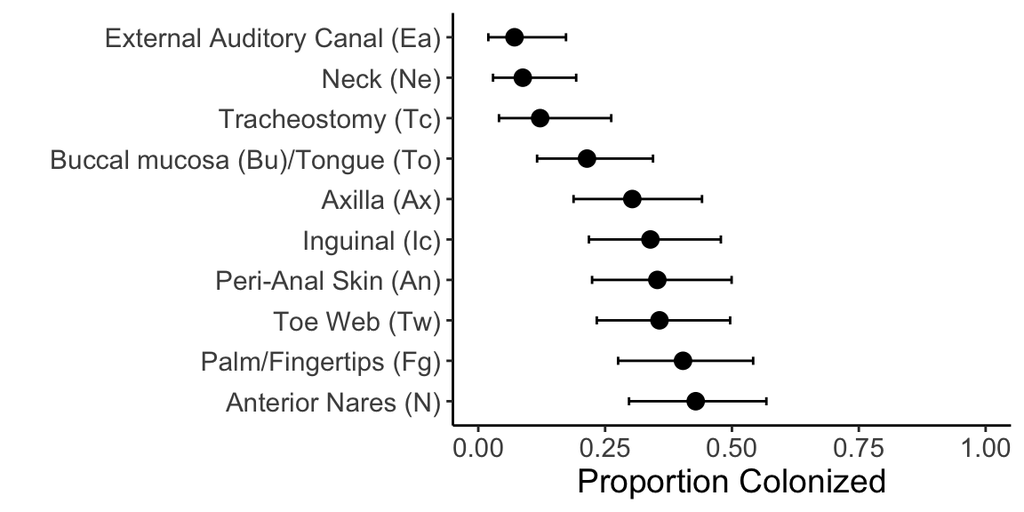

```r
CI.single$site = as.factor(rownames(CI.single))
colnames(CI.single) = c("Prevalence", "95% CI, Lower", "95% CI, Upper", "N.Sites", "SiteID")
CI.single = plyr::join(CI.single, site_codes)
CI.single$Site.Extended = as.factor(as.character(CI.single$Site.Extended))
ordering = forcats::fct_inorder(levels(CI.single$Site.Extended))
CI.single$Habitat = str_replace_all(CI.single$Habitat, "Stool", "GI Tract")
CI.single$Habitat = str_replace_all(CI.single$Habitat, "Oral", "GI Tract")
Figure1A = ggplot(CI.single, aes(y =  `Prevalence`,
                                       x = forcats::fct_inorder(Site.Extended))) +
        geom_point(size=3) +
        theme_classic() +
        geom_errorbar(aes(ymin=`95% CI, Lower`,
                          ymax=`95% CI, Upper`), width=.2,
                 position=position_dodge(.9))  + xlab("") + coord_flip() +
        ylim(0, 1) + ylab("Proportion Colonized")+
  theme(text = element_text(size = 14 ))

Figure1A
```

#### Figure 1B: Sensitivity analysis identifying sites that capture observed prevalence of C. auris colonization based on different pairings of sites

- note that we do not have data for false positives and false negatives; therefore, we cannot formally compute sensitivity, which is defined as TP / (TP+FN). Due to the lack of FP/FN data our prevalence and sensitivity estimates are equal. Instead, sensitivity is defined by dividing the "estimated site-wise prevalence" by the number of colonized subjects using all sites (0.8070175)
- A minimum of 6 sites was required to achieve 100% sensitivity, capturing all colonized individuals.

Figure 1: Surveillance of multiple skin, nares, perianal, oral body sites for prevalence and bioburden of C. auris colonization. Sensitivity analysis to calculate the proportion of colonized individuals captured by performing surveillance on different pairings of sites. Sensitivity is defined as the Proportion Colonized at each site divided by the total number of individuals identified as colonized at any body site. From left to right, the two vertical lines correspond to the sensitivity of Axilla/Inguinal Crease and Axilla/Inguinal Crease/ Nares. A minimum of 6 sites was required to achieve 100% sensitivity, capturing all colonized individuals.

```r
true.prevalence.t1 =  0.8070175

sensitivity = data.frame(CI.combo[,1:3]/true.prevalence.t1, CI.combo[,4])
colnames(sensitivity) = c("Sensitivity", "95% CI, Lower", "95% CI, Upper", "N.Sites")
sensitivity$Site = rownames(sensitivity)
sensitivity = subset(sensitivity, N.Sites <7)

sensitivity = sensitivity %>%
  arrange(., desc(Sensitivity))
sensitivity$name <- factor(sensitivity$Site, levels = sensitivity$Site)


#make plot
#let's annotate by adding lines at "Ax, Ic" and with "Ax, Ic, N"  rather than including them as data points
myannotations = subset(sensitivity, name %in% c("Ax, Ic","Ax, Ic, N"))
sensitivity1 = subset(sensitivity, !(name %in% c("Ax, Ic","Ax, Ic, N")))

ax.ic = data.frame(subset(sensitivity, name == "Ax, Ic"))$Sensitivity

ax.ic.n = data.frame(subset(sensitivity, name == "Ax, Ic, N"))$Sensitivity
ax.ic
```

```
## [1] 0.6195653
```

```r
ax.ic.n
```

```
## [1] 0.7965839
```

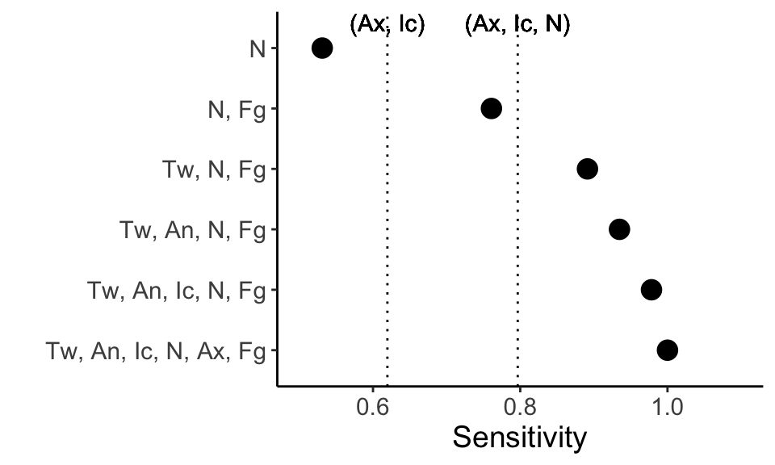

```r
#relabel the site codes
sensitivity1$name = plyr::revalue(sensitivity1$name,
                        c("N, Ic, Fg, Tw" = "N, Fg, Tw,  Ic",
                          "N, Ic, Fg, Tw, An" = "N, Fg, Tw,  Ic, An",
                          "N, Ax, Ic, Fg, Tw, An" = "N, Fg, Tw,  Ic, An, Ax"))




Figure1C = ggplot(sensitivity1, aes(y =  `Sensitivity`,
                                       x = `name`)) +
        geom_point(size=4) +
        theme_classic()  + xlab("") + coord_flip() +
        labs(col="Number of sites")  +ylab("Sensitivity") +
        geom_hline(yintercept = ax.ic , linetype = "dotted") +
        geom_text(aes(6, ax.ic,label = "(Ax, Ic)", vjust = -1)) +
        geom_hline(yintercept = ax.ic.n, linetype = "dotted" ) +
        geom_text(aes(6, ax.ic.n,label = "(Ax, Ic, N)", vjust = -1))+
        ylim(0.5, 1.1)+
  theme(text = element_text(size = 14 ))
Figure1C
```

#### Supplementary Figure 2: Ridgeline plot for samples across sites during the first survey.

Supplementary Figure 2: Ridgeline plot for sample colony counts across sites during the first survey. The cumulative distribution for each ridgeline sums to 1, with peaks corresponding to peak bioburden (log colony forming units), for each site. Sites with low level colonization include Sebaceous sites (External Auditory Canal, Neck) while sites having the highest bioburden include Nares and Inguinal crease.

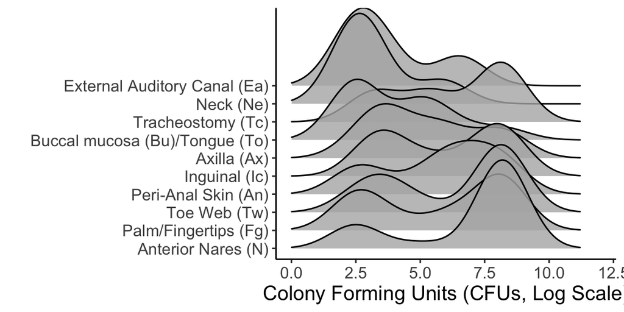

```r
mpn$CFU.Missing = is.na(mpn$CFUTransform_Cauris)
mpn$Log.cfu = log(mpn$CFUTransform_Cauris)
mpn$sqrt.cfu = sqrt(mpn$CFUTransform_Cauris)
cfu = subset(mpn, CFU.Missing==FALSE) %>%
  subset(., CFUTransform_Cauris > 1)  %>%
  subset(., Survey_Period == 1) %>%
  dplyr::select(., c("Log.cfu", "SiteID")) %>%
  plyr::join(., site_codes)

cfu$Habitat = str_replace_all(cfu$Habitat, "Oral", "GI Tract")
cfu$Habitat = str_replace_all(cfu$Habitat, "Stool", "GI Tract")

foo = arrange(Figure1A$data, -Prevalence)
ordering = foo$Site.Extended

cfu$Site.Extended2 <- factor(cfu$Site.Extended, levels = ordering)
SupplementaryFigure3= ggplot(cfu, aes(x = Log.cfu, y = Site.Extended2)) +
  geom_density_ridges(scale = 5, alpha=0.8) + theme_classic() + xlim(0, 12) +
  ylab("") + xlab("Colony Forming Units (CFUs, Log Scale)") + theme(text = element_text(size = 14))

SupplementaryFigure3
```

#### Figure 1C: MPN counts differ by body site and are highest at the nares

Figure 1: Surveillance of multiple skin, nares, perianal, oral body sites for prevalence and bioburden of C. auris colonization.

```r
mpn =  dplyr::select(mpn, c("Unique_ptid", "Survey_Period", "Cauris_Result", "site",
                     "CDC_MPN")) %>%
  plyr::join(., site_codes)  %>%
  subset(., SiteID %in% c("Ax", "N", "Ic")) %>%
  subset(., Survey_Period==1)

mpn = subset(mpn, CDC_MPN > 0)
mpn$CDC_MPN_Mod = mpn$CDC_MPN
mpn$CDC_MPN_Mod <- ifelse(is.na(mpn$CDC_MPN_Mod), mpn$Cauris_Result, mpn$CDC_MPN_Mod)

dfa = subset(mpn, SiteID %in% c("N", "Ic"))
dfa$subset = "a"
dfa$logMPN = log(1+dfa$CDC_MPN_Mod)
dfb = subset(mpn, SiteID %in% c("N", "Ax"))
dfb$subset = "b"
dfb$logMPN = log(1+dfb$CDC_MPN_Mod)
newdf = data.frame(rbind(dfa, dfb))
ordering = c("Anterior Nares (N)", "Axilla (Ax)", "Inguinal (Ic)")

newdf$Site.Extended <- factor(newdf$Site.Extended, levels = ordering)
mpn$Site.Extended <- factor(mpn$Site.Extended, levels = ordering)

table(mpn$Site.Extended)
```

```
##
## Anterior Nares (N)        Axilla (Ax)      Inguinal (Ic)
##                 19                 14                 16
```

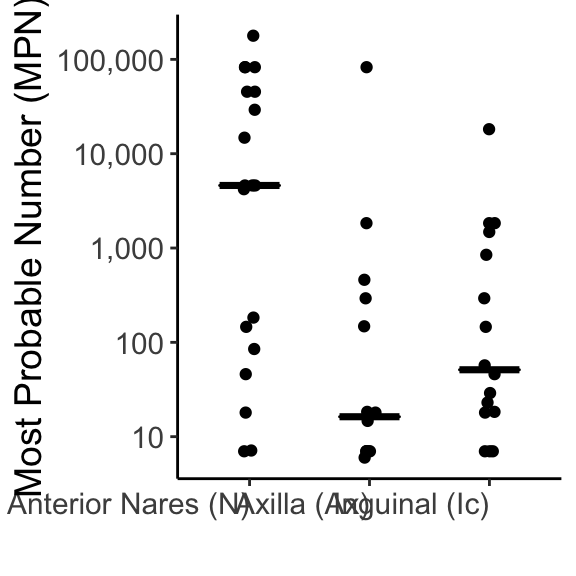

```r
#make the figure
Figure1B =
  ggplot(mpn, aes(x = factor(Site.Extended,
                   level = c("Anterior Nares (N)", "Axilla (Ax)", "Inguinal (Ic)")),
                 y = CDC_MPN))  +
    stat_summary(fun = median, fun.min = median, fun.max = median,
                 geom = "crossbar", width = 0.5) +
  geom_jitter(width=0.05) +
  theme_classic()  + scale_y_log10(label=comma) +
  xlab("") + ylab("Most Probable Number (MPN)")   +
    theme(text = element_text(size=14),
        axis.text.x = element_text(angle=0, hjust=1))
Figure1B
```

#### Figure 1: Surveillance of multiple skin, nares, anal, oral body sites for prevalence and patient-level bioburden of C. auris colonization.

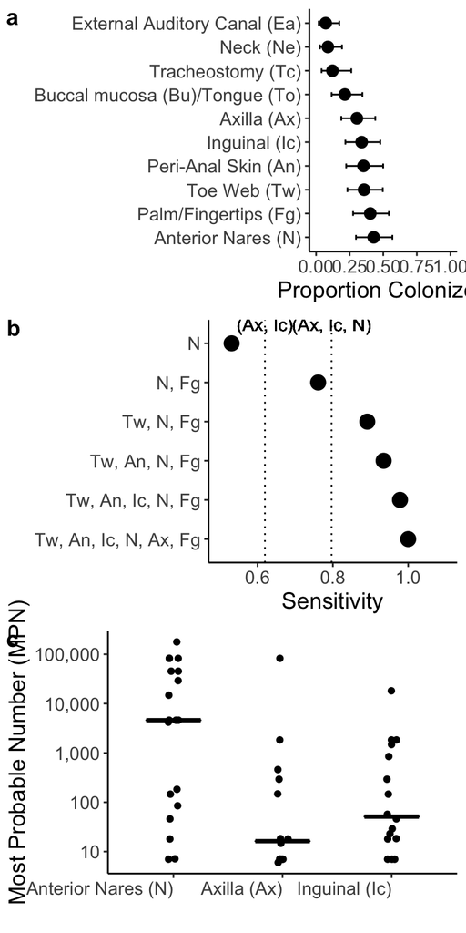

```r
cowplot::plot_grid(
  Figure1A,
  Figure1C,
  Figure1B,
  labels=c("a", "b", "c"), ncol=1,
  rel_heights = c(1,1, 1),
  rel_widths = c(1,1, 1)
)
```

```r
ggsave(Figure1A, file="~/Desktop/proctor_manuscript/Figure1/Figure1a.eps", device="eps")
ggsave(Figure1B, file="~/Desktop/proctor_manuscript/Figure1/Figure1b.eps", device="eps")
ggsave(Figure1C, file="~/Desktop/proctor_manuscript/Figure1/Figure1c.eps", device="eps")

#save to pdf
ggsave(cowplot::plot_grid(
  Figure1A,
  Figure1B,
  NULL,
  Figure1C,
  labels=c("a", "b", "", "c"), ncol=2,
  rel_heights = c(1,1, 1,1),
  rel_widths = c(1.1,1, 1.1, 1)
), file="~/Desktop/proctor_manuscript/Figure1/Figure1.pdf", width = 12, height = 9, device="pdf")

#save to eps
ggsave(cowplot::plot_grid(
  Figure1A,
  Figure1B,
  NULL,
  Figure1C,
  labels=c("a", "b", "", "c"), ncol=2,
  rel_heights = c(1,1, 1,1),
  rel_widths = c(1.1,1, 1.1, 1)
), file="~/Desktop/proctor_manuscript/Figure1/Figure1.eps", width = 12, height = 9, device="eps")
```

#### Supplementary Figure 1: Patterns of body site occupancy visualized with UpSetR.

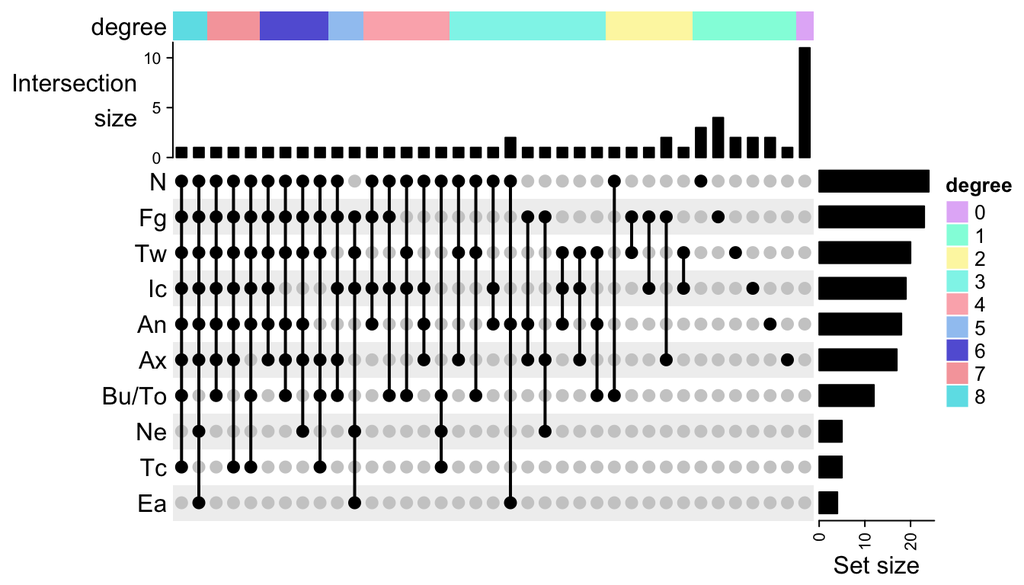

```r
############# Let's subset on the first time point so that we don't have 2-3 entries per patient
newdata1 = subset(data, Survey_Period==1)

#note that subject 29 was not sampled on day 1, just on day 2, so let's grab that individual, subsetting on time point 2 only
subject29 = subset(data, Unique_ptid=="29" & Survey_Period=="2")
newdata1 = data.frame(rbind(newdata1, subject29))
newdata2 = newdata1  %>%
    subset(., SiteID != "Ax, Ic")
newdata3 = dplyr::select(newdata2, c("Unique_ptid", "SiteID", "Cauris_Result"))


#verify we have 57 subjects
#length(unique(newdata3$Unique_ptid))
rownames(newdata3) = NULL


cast.df<-dcast(newdata3, Unique_ptid~SiteID, value.var="Cauris_Result")
cast.df[is.na(cast.df)] = 0

#make the heatmap
m = make_comb_mat(cast.df)

UpSet(m, top_annotation = HeatmapAnnotation(
    degree = as.character(comb_degree(m)),
    "Intersection\nsize" = anno_barplot(comb_size(m),
        border = FALSE,
        gp = gpar(fill = "black"),
        height = unit(2, "cm")
    ),
    annotation_name_side = "left",
    annotation_name_rot = 0))
```

### How many people are person colonized at >=3 sites?

- wee can see that 46 people were colonized at one or more site

```r
foo = cast.df
rownames(foo) = foo$Unique_ptid
foo$Unique_ptid = NULL
foo$N.positive = rowSums(foo)

tab = data.frame(table(foo$N.positive))

#number of people colonized at 1 sites
14/46
```

```
## [1] 0.3043478
```

```r
#number of people colonized at >2 sites
sum(tab$Freq[3:9])/46
```

```
## [1] 0.6956522
```

```r
#number of people colonized at >3 sites
sum(tab$Freq[4:9])/46
```

```
## [1] 0.5652174
```

#### Supplementary Figure 3 - paired MPN analysis

Supplementary Figure 3: Paired Most Probable Number (MPN). MPN estimates are shown for the inguinal crease, anterior nares, and axilla. Data represented are from the first point prevalence survey. Each line represents an individual. Individual trajectories reveal a large number of individuals with high counts at the nares and either absent or low level colonization at the axilla or inguinal crease

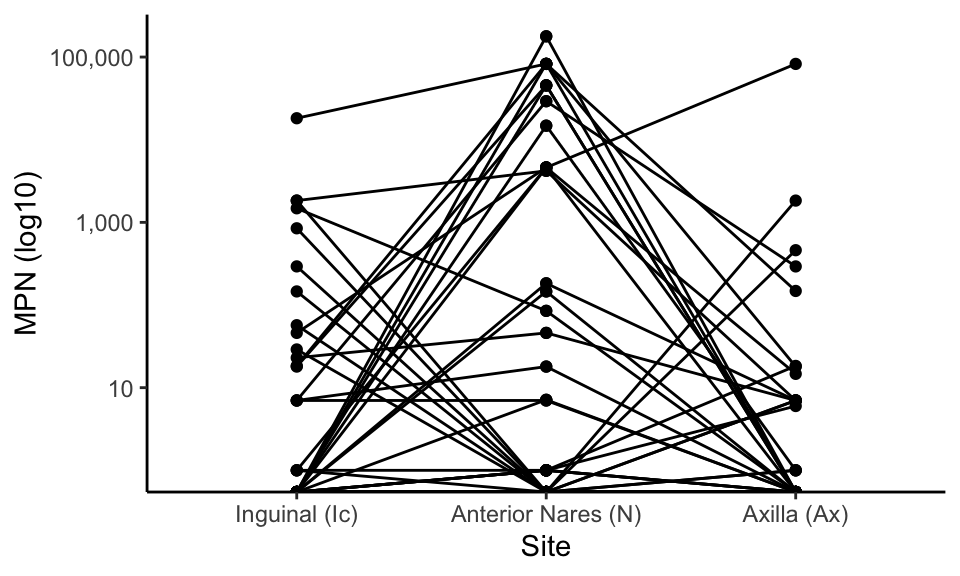

```r
mpn = read.csv("~/Desktop/candida_auris_rush/manuscript/data/Cauris_Analytic_2020-5-20.csv") %>%
  dplyr::select(., c("Unique_ptid", "Survey_Period", "Cauris_Result", "site",
                     "CDC_MPN")) %>%
  plyr::join(., site_codes)  %>%
  subset(., SiteID %in% c("Ax", "N", "Ic")) %>%
  subset(., Survey_Period==1)


mpn$CDC_MPN_Mod = mpn$CDC_MPN
mpn$CDC_MPN_Mod <- ifelse(is.na(mpn$CDC_MPN_Mod), mpn$Cauris_Result, mpn$CDC_MPN_Mod)

ordering = c("N", "Ax", "Ic")
mpn$SiteID  <- factor(mpn$SiteID, levels = ordering)

dfa = subset(mpn, SiteID %in% c("N", "Ic"))
dfa$subset = "a"
dfa$logMPN = log(1+dfa$CDC_MPN_Mod)
dfb = subset(mpn, SiteID %in% c("N", "Ax"))
dfb$subset = "b"
dfb$logMPN = log(1+dfb$CDC_MPN_Mod)
newdf = data.frame(rbind(dfa, dfb))
ordering = c("Ax", "N", "Ic")
newdf$SiteID <- factor(newdf$SiteID, levels = ordering)

SupplementaryFigure4 =
  ggplot(newdf, aes(x = factor(Site.Extended,
                   level = c("Inguinal (Ic)" ,  "Anterior Nares (N)",   "Axilla (Ax)"  )),
                 y = CDC_MPN_Mod, group=Unique_ptid)) +
  geom_point() +
  geom_line()  +
  theme_classic()  + scale_y_log10(label=comma) +
  theme(
  strip.background = element_blank(),
  strip.text.x = element_blank()
)+ xlab("Site") + ylab("MPN (log10)")
SupplementaryFigure4
```